# team.Rmd

## Question 7: Is there any correlation between the political affiliation of a person and their sex? Generally where does each sex stand on the political spectrum the most?

We wanted to find out if there was any similarities between how people of different genders vote. There seems to be about one big similarity between them and that is that both females and males say they are not strong democrats; the rest of the data is different. The females seem to have more responses in specific parties like strong democrat and independent, whereas the males seem to have spread out their votes evenly between all parties.

Below are the variables being used and their values.  
sex:  
-male  
-female  
Political Affiliation:  
-Indepedent  
-Ind,near dem  
-Ind,near rep  
-Not Strong Democrat  
-Not Strong Republican  
-Strong Democrat  
-Strong Republican

```r
dat3 <- subset(dat1, marital_status != "No answer" & political_affiliation != "No answer" & political_affiliation != "Don't know" &  political_affiliation != "Other party")
```

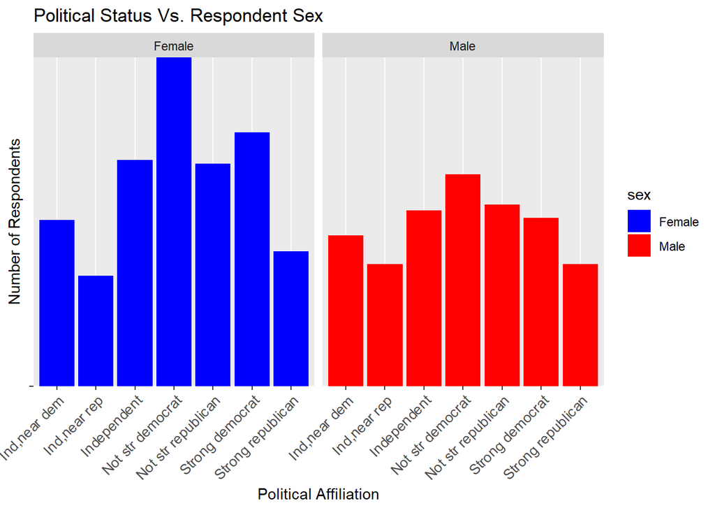

```r
politics<-ggplot(dat3, aes(x=political_affiliation, y='', fill=sex)) +
         theme(axis.text.x =
                   element_text(size  = 10,
                                angle = 45,
                                hjust = 1,
                                vjust = 1)) +
         geom_bar(position="stack", stat="identity") +
         scale_fill_manual(values=c("blue", "red")) +
         facet_grid(. ~ sex, space="free_x", scales="free_x") + labs(x = "Political Affiliation", y = "Number of Respondents", title = "Political Status Vs. Respondent Sex")
politics
```